# info201_Final_Report

Tyler Ngo, Sam Mixon, Anna Carpio, and Lanvinia Bartose

2024-06-01

# Abstract

# Introduction

As residents and students in Seattle, we recognize the importance of understanding the dynamics of crime within our city. Through this report, we aim to shed light on the various types of crimes occurring in Seattle, fostering awareness among students, faculty, residents, and prospective residents.

While Seattle offers vibrant opportunities for living and education, it’s crucial to acknowledge the realities of urban life, including the presence of crime. It is widely known that in large cities such as Seattle, criminal incidents tend to occur more frequently due to a combination of things. For example factors such as population density, socio-economic disparities, and geographical features can play a role in crime rates. Based on this understanding, we have formulated several key questions that we seek to explore: - How have crime rates in Seattle fluctuated over the past decade, and what are the primary factors contributing to these changes? - Are certain neighborhoods or areas within Seattle experiencing disproportionately high or low crime rates, and what socioeconomic factors might be influencing these patterns? - What types of crimes are most prevalent in Seattle, and how do they compare to national trends? - How effective have recent crime prevention and law enforcement initiatives been in Seattle, and what strategies show promise for further reducing crime rates in the future?

By analyzing the data we have gathered, we seek to provide a comprehensive overview of the prevalent types and locations of crime in our city.

Our intention is not to discourage residing or studying in Seattle, but rather to empower our community with the knowledge to take informed safety measures. We hope to equip our peers with valuable insights to navigate and thrive in our urban environment.

# Data Explanation

We used two publicly available datasets from the City of Seattle for our analysis:

Call Data for the Seattle Police Department (SPD)– This dataset provides information about calls for service received in specific beats (geographic areas used to organize police activity). It also categorizes where crimes take place or where incidents requiring a police response occur. Seattle Police Department 911 Incident Response Records– This dataset details police responses to incidents reported through 911 calls.

These datasets were merged to create a combined dataset containing information on crime incidents in Seattle. The merged dataset has dimensions of 288 rows (representing individual crime incidents) and 12 columns containing various attributes.The datasets are freely available for public use under the City of Seattle’s open data policy. This policy ensures that the data can be accessed, used, and shared by anyone, including for commercial purposes, without restrictions.During our analysis, we encountered several data quality issues. Both datasets had instances of missing values, particularly in location data. Some entries had non-plausible values, such as negative response times in the emergency call data. We addressed these issues through data cleaning methods, such as removing rows with critical missing values and correcting non-plausible entries based on logical assumptions.

Website link to datasets:  
[https://www.kaggle.com/datasets/sohier/seattle-police-department-911-incident-response?resource=download]  
[https://data.seattle.gov/Public-Safety/Call-Data/33kz-ixgy/data_preview]

# Method

**Key Variables:**  
*Event_Clearance_Description (String)*: This coded variable describes the outcome of the police response to the incident (e.g., arrest made, case closed).  
*Priority (Numeric)*: This variable indicates the priority level assigned to the incident call (typically 1-3, with 1 being the most critical).  
*Incident_Outcome (String)*: This coded variable details the final outcome of the incident (e.g., unfounded complaint, citation issued).  
*Beat (String)*: This coded variable identifies the specific police patrol area where the incident occurred.  
*Response_Duration (Numeric)*: This variable measures the time elapsed between the initial call dispatch and officer arrival on the scene.

# Results

This is the duration of a response, or how long it took to clear an incident compared to its level of priority. The priority of a call is directly related to how serious the crime or situation is.

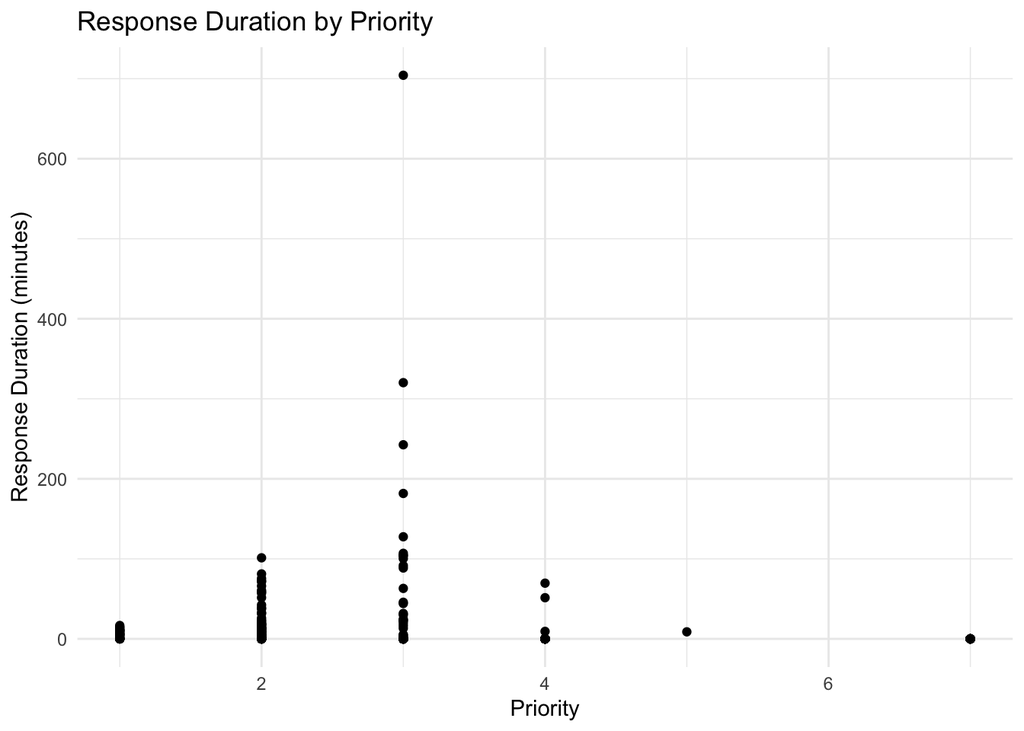

The bar graph represents the comparison in the number of crime related incidents that occur based on the time of day.

The incident count during the afternoon/evening is larger than morning/daytime, suggesting higher crime occurrence during evening hours.

This insight can help in planning police patrols to focus on these high-risk periods.

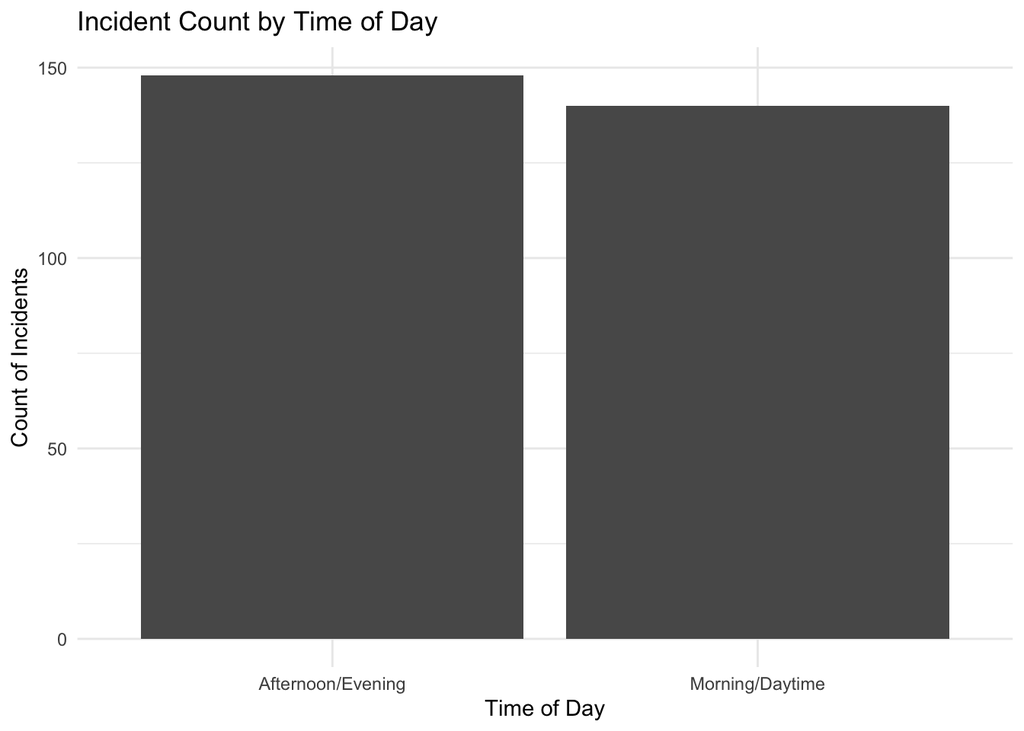

These are the Beats with the highest number of incidents we found in the data.

Highest crime neighborhoods had incidents counts of 7 or higher.

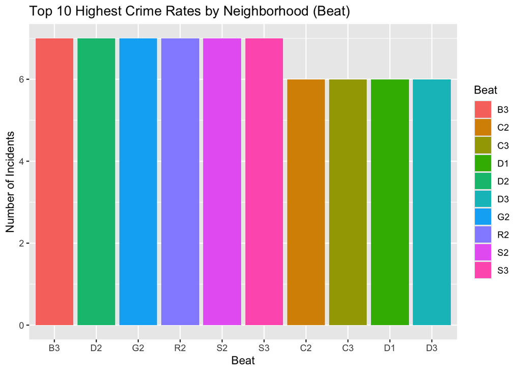

This is the number of responses by the SPD to the various calls they responded to.

Duplicated/cancelled by radio, other report made, and assistance rendered were the most common outcomes.

This suggests that a large portion of police responses and incidents do not result in major interventions or arrests.

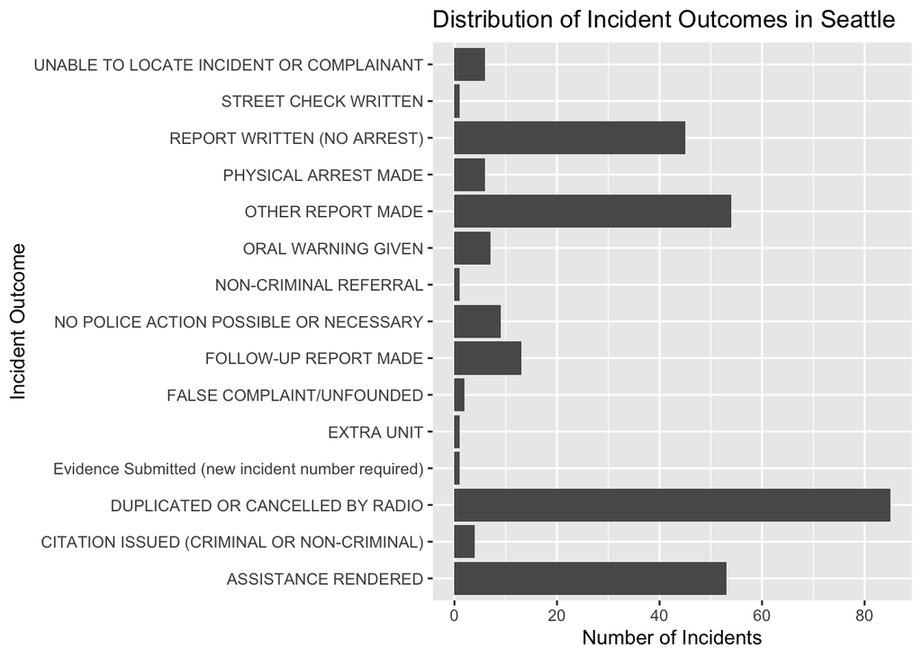

This line plot represents the incident count recorded in both our datasets throughout the years from 2010 to 2017.

The number of incidents occurred and recorded peaked in 2010 and began declining in the following years.

However, the number of incidents would increase again approaching 2016.

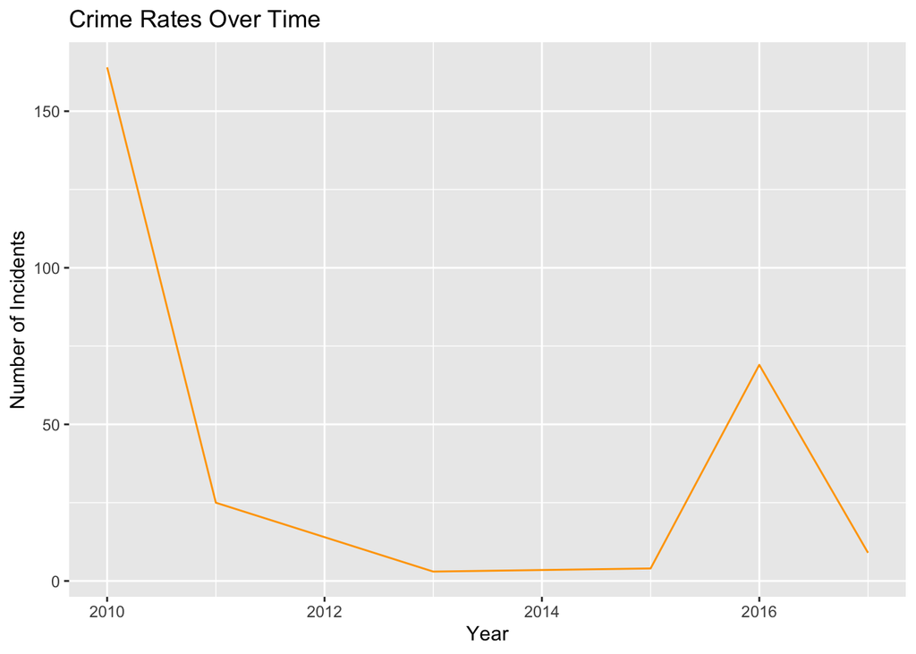

# Findings

Finally, crime tends to be more frequent in the afternoon and at night. This could be due to various factors and is something to consider for personal safety. By being aware of these peak times, residents can take precautions and be more vigilant during those hours.

# Summary